# Spore shape vs. size

This is an R Notebook containing code and results of comparing the performance of shape and size traits for discrimination of species in *Subulicystidium*.

**New in this version**:  
* this is largely a duplicate of the version 20210129 but now based on the (for sureness) re-run PCA from 17.02.2021  
* removed the non-relevant here description of how to create a single NEF file. * make illustrations and tables writing to the files with desired dimensions, into kind of ‘out’ folder

**To do in the next version**:  
* implement report() in the end of the script * move PCA analysis of NEFD to R  
* I may also adjust longisporum name in the next analysis version when the data from Christina will be coming. Then my longisporum will become longisporum_7

**Most important changes in the past**: * analyses on image-level data, N of observations = 401. Each observation is a data from a single image, with information on min 1 spore and max 4 spores  
* custom function for discriminant analysis that allows to shorten the script

## Setting the work

### All is pre-set correctly now

All code, data and results are organized into RStudio R project. After clicking the .Rproj file, this Notebook will be opened and working directory will be understood by R correctly as a directory which is parent for the code, data and results directories.

additionally, loading package “here” should notify on the correct working directory. “here” will be also very helpful for accessing files in the child directories along the script.

```r
library(here)
library(conflicted)
conflict_prefer("here", "here")
```

```
[conflicted] Will prefer here::here over any other package
```

```r
conflicted::conflict_prefer("rename", "dplyr")
```

```
[conflicted] Will prefer dplyr::rename over any other package
```

### This is how it was earlier

At the very start, assign in R studio as a working directory the directory which is parent for the code, data and results directories. Then *set_here* function of the “here” package will pick this assignment by creating the file .here. Then all subsequent R sessions on this project will start with the right directory. To see more examples of “here” visit this [link](http://jenrichmond.rbind.io/post/where-is-here/)

## Load and proceed spore shape data

### Summarize symmetric variation

Load and process the table with PCA scores of the spores (symmetric variation)

```r
scores_symm_raw <- read.csv(here("2_3_data_shape", "pca_202102", "1_symm", "30specimens_clean_symm.pcs"),  sep="\t")

# add columns to be filled in later with relevant IDs
scores_symm_raw <- cbind(Specimen_ID = NA, scores_symm_raw)
scores_symm_raw <- cbind(Image_ID = NA, scores_symm_raw)

# fill in column Specimen_ID based on the content of the column DATA_NAME
library(stringr)
strings <- c("^ARAN", "^CWU", "^KHL", "^LR", "^LY", "^Ordynets")
scores_symm_raw$Specimen_ID <- ifelse(str_detect(scores_symm_raw$DATA_NAME, paste(strings, collapse = "|")), gsub("^([^_]*_[^_]*)_.*$", "\\1", scores_symm_raw$DATA_NAME), gsub("^([^_]*_[^_]*_[^_]*)_.*$", "\\1", scores_symm_raw$DATA_NAME))

# fill in column Image_ID based on the content of the column DATA_NAME
scores_symm_raw$Image_ID <- ifelse(str_detect(scores_symm_raw$DATA_NAME, paste(strings, collapse = "|")), gsub("^([^_]*_[^_]*_[^_]*_[^_]*)_.*$", "\\1", scores_symm_raw$DATA_NAME), gsub("^([^_]*_[^_]*_[^_]*_[^_]*_[^_]*)_.*$", "\\1", scores_symm_raw$DATA_NAME))
```

Plot PCA scores as scatterplots (symmetric variation)

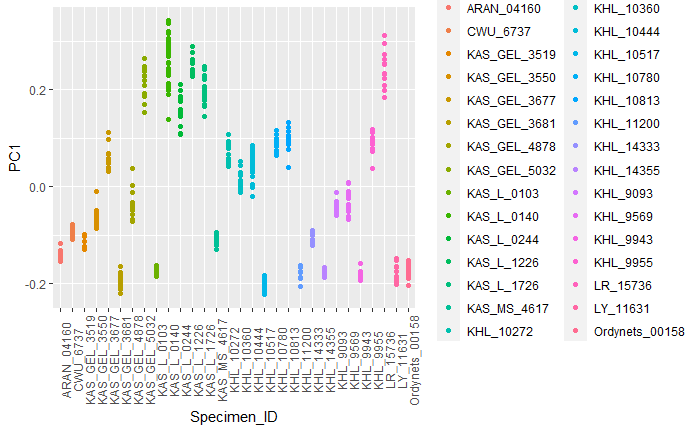

```r
library(ggplot2)
pca_symm_plot<-ggplot(scores_symm_raw, aes(x=Specimen_ID, y=PC1, color=Specimen_ID)) +
geom_point()+
theme(axis.text.x = element_text(angle = 90))
plot(pca_symm_plot)
```

Summarize symmetric variation at the image ID level `.groups = 'drop'` argument in `summarise()` will help to remove a “friendly warning”  
`` `summarise()` ungrouping output (override with `.groups` argument) ``  
The explanation is available [here](https://stackoverflow.com/questions/62140483/how-to-interpret-dplyr-message-summarise-regrouping-output-by-x-override)

```r
library(dplyr)
scores_symm_summ <- scores_symm_raw %>%
  group_by(Image_ID) %>%
  summarise(across(Specimen_ID, dplyr::first),
            across(PC1, mean),
            .groups = 'drop')
scores_symm_summ <- dplyr::rename(scores_symm_summ, PC1_symm_mean = PC1)
```

### Summarize asymmetric variation

Load and process the table with PCA scores for spores (asymmetric variation)

```r
scores_asym_raw <- read.csv(here("2_3_data_shape", "pca_202102", "2_asym", "30specimens_clean_asym.pcs"),  sep="\t")

# add columns to be filled in later with relevant IDs
scores_asym_raw <- cbind(Specimen_ID = NA, scores_asym_raw)
scores_asym_raw <- cbind(Image_ID = NA, scores_asym_raw)

# fill in column Specimen_ID based on the content of the column DATA_NAME.
# "strings" object was created above and is valid here as is.
# Package "stringr" is necessary and was loaded earlier.
scores_asym_raw$Specimen_ID <- ifelse(str_detect(scores_asym_raw$DATA_NAME, paste(strings, collapse = "|")), gsub("^([^_]*_[^_]*)_.*$", "\\1", scores_asym_raw$DATA_NAME), gsub("^([^_]*_[^_]*_[^_]*)_.*$", "\\1", scores_asym_raw$DATA_NAME))

# fill in column Image_ID based on the content of the column DATA_NAME.
scores_asym_raw$Image_ID <- ifelse(str_detect(scores_asym_raw$DATA_NAME, paste(strings, collapse = "|")), gsub("^([^_]*_[^_]*_[^_]*_[^_]*)_.*$", "\\1", scores_asym_raw$DATA_NAME), gsub("^([^_]*_[^_]*_[^_]*_[^_]*_[^_]*)_.*$", "\\1", scores_asym_raw$DATA_NAME))
```

Plot PCA scores as scatterplots (asymmetric variation): PC1 vs PC2

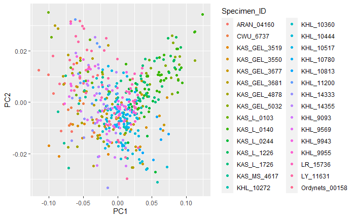

```r
library(ggplot2)
pca_asym_plot<-ggplot(scores_asym_raw, aes(x=PC1, y=PC2, color=Specimen_ID)) +
geom_point()
plot(pca_asym_plot)
```

Plotting PCA scores as scatterplots (asymmetric variation): PC1 vs PC3

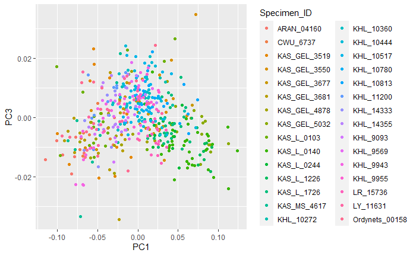

```r
library(ggplot2)
pca_asym_plot<-ggplot(scores_asym_raw, aes(x=PC1, y=PC3, color=Specimen_ID)) +
geom_point()
plot(pca_asym_plot)
```

Summarize asymmetric variation at image level

```r
library(dplyr)
scores_asym_summ <- scores_asym_raw %>%
  group_by(Image_ID) %>%
  summarise(PC1_asym_mean=mean(PC1),
            PC2_asym_mean=mean(PC2),
            PC3_asym_mean=mean(PC3),
            .groups = 'drop')
```

### Summarize global variation

Load and process the table with PCA scores for spores (global variation)

```r
scores_glob_raw <- read.csv(here("2_3_data_shape", "pca_202102", "3_glob", "30specimens_clean_glob.pcs"),  sep="\t")

# add columns to be filled in later with relevant IDs
scores_glob_raw <- cbind(Specimen_ID = NA, scores_glob_raw)
scores_glob_raw <- cbind(Image_ID = NA, scores_glob_raw)

# fill in column Specimen_ID based on content of the column DATA_NAME
# "strings" object was created above and is valid here as is
# Package "stringr" is necessary and was loaded earlier
scores_glob_raw$Specimen_ID <- ifelse(str_detect(scores_glob_raw$DATA_NAME, paste(strings, collapse = "|")), gsub("^([^_]*_[^_]*)_.*$", "\\1", scores_glob_raw$DATA_NAME), gsub("^([^_]*_[^_]*_[^_]*)_.*$", "\\1", scores_glob_raw$DATA_NAME))

scores_glob_raw$Image_ID <- ifelse(str_detect(scores_glob_raw$DATA_NAME, paste(strings, collapse = "|")), gsub("^([^_]*_[^_]*_[^_]*_[^_]*)_.*$", "\\1", scores_glob_raw$DATA_NAME), gsub("^([^_]*_[^_]*_[^_]*_[^_]*_[^_]*)_.*$", "\\1", scores_glob_raw$DATA_NAME))
```

Plotting PCA scores as scatterplots (global variation): PC1 vs PC2

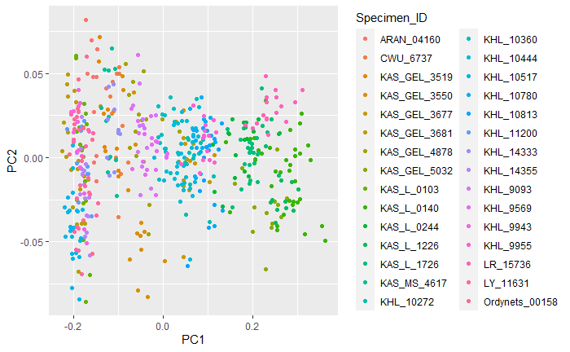

```r
library(ggplot2)
pca_glob_plot<-ggplot(scores_glob_raw, aes(x=PC1, y=PC2, color=Specimen_ID)) +
geom_point()
plot(pca_glob_plot)
```

Summarize global variation at the image level

```r
library(dplyr)
scores_glob_summ <- scores_glob_raw %>%
  group_by(Image_ID) %>%
  summarise(PC1_glob_mean=mean(PC1),
            PC2_glob_mean=mean(PC2),
            .groups = 'drop')
```

## Load and proceed spore size data

Spore size data from separate specimens get pooled.  
I will suppress the warning message “Missing column names filled in: ‘X1’ [1]” that is generated by “read.csv” function which is forced to give a name to the unnamed column.

```r
library(here)
library(readr)
import.size <- dir(here("2_2_data_size", "v20201215"), pattern = "*.csv", full.names = T)
data_size_raw <- suppressWarnings(plyr::ldply(import.size, read_csv))
```

Then the spreadsheet is transformed to put length and width of each spore into separate columns of one row.  
Warning message from dplyr when binding length and width columns “New names: * X1 -> X1…1…” that appears after the code chunk can be ignored.  
Then, length to width ratio is added as an additional column.  
Finally, column “Image_ID” is created.

```r
library(dplyr)
# find spore lengths
data_size_raw_odd <- data_size_raw %>% dplyr::slice(which(row_number() %% 2 == 1))
colnames(data_size_raw_odd)[which(names(data_size_raw_odd) == "Label")] <- "Photo_ID"

# find spore widths
data_size_raw_even <- data_size_raw %>% dplyr::slice(which(row_number() %% 2 == 0))
colnames(data_size_raw_even)[which(names(data_size_raw_even) == "Length")] <- "Width"

# bind length and width values and leave just necessary values
data_size_tiny <- bind_cols(data_size_raw_odd, data_size_raw_even)
```

```
* X1 -> X1...1
* Min -> Min...3
* Max -> Max...4
* Angle -> Angle...5
* X1 -> X1...7
* ...
```

```r
data_size_tiny_simple <-data_size_tiny[, c("Photo_ID", "Length", "Width")]

# add length to width ratio as an additional trait
data_size_tiny_simple <- transform(data_size_tiny_simple, Length_to_width_ratio = Length / Width)
data_size_tiny_simple$Length_to_width_ratio <- round(data_size_tiny_simple$Length_to_width_ratio, 2)

# add column for image IDs
data_size_tiny_simple <- cbind(Image_ID = NA, data_size_tiny_simple)

# fill the column for image IDs
## code that uses regex is based on the solution for gsub
## ## https://stackoverflow.com/questions/39366759/regex-to-extract-values-between-2-underscores-including-a-value-that-is-an-unde
## https://stackoverflow.com/questions/7449564/regex-return-all-before-the-second-occurrence

library(stringr)
strings <- c("^ARAN", "^CWU", "^KHL", "^LR", "^LY", "^Ordynets")
data_size_tiny_simple$Image_ID <- ifelse(str_detect(data_size_tiny_simple$Photo_ID, paste(strings, collapse = "|")), gsub("^([^_]*_[^_]*_[^_]*_[^_]*)_.*$", "\\1", scores_symm_raw$DATA_NAME), gsub("^([^_]*_[^_]*_[^_]*_[^_]*_[^_]*)_.*$", "\\1", data_size_tiny_simple$Photo_ID))

#remove ".bmp" string pattern from some image IDs
data_size_tiny_simple$Image_ID <- gsub(pattern = ".bmp*", replacement = "", x = data_size_tiny_simple$Image_ID)
```

Summarize size data at the image level

```r
library(dplyr)
size_summ <- data_size_tiny_simple %>%
  group_by(Image_ID) %>%
  summarise(Length_mean=mean(Length),
            Width_mean=mean(Width),
            Length_to_width_ratio_mean=mean(Length_to_width_ratio),
            N_spores = n(),
              .groups = 'drop')
```

The chunk below allows to add a variable with an alternative size definition, following Claude 2008 book (p. 98-99).  
It is a possible alternative to the single length and width measurements.  
This measure of size would correlate less with shape variables, which is a desired behavior.  
However, if used in in discriminant analysis, it did not allow to gain in species prediction (tried in Feb 2020, not shown in the code below but can be easily added).

```r
## needs dplyr
# size_summ$Size_scaled <- NA
# size_summ$Size_scaled <- sqrt(size_summ$Length_mean * size_summ$Width_mean)
# size_summ <- size_summ %>% relocate(Size_scaled, .before = 'Length_mean') # cosmetic changes
```

## Unite shape and size data

### Check that Images IDs are in the same order in all objects. They will serve as grouping variable

Check for image level data (n=401 in Dez 2020). Here, no need to sort the data in each group because they are all in the sam order after applying `summarise()` function

```r
sapply(list(scores_symm_summ$Image_ID, scores_asym_summ$Image_ID, scores_glob_summ$Image_ID),
            FUN = all.equal.list, size_summ$Image_ID)
```

```
[1] TRUE TRUE TRUE
```

### Create a united table with all traits

Join separate dataframes

```r
library(dplyr)
traits_merged <- scores_symm_summ %>% right_join(scores_asym_summ, by = "Image_ID") %>% right_join(scores_glob_summ, by = "Image_ID") %>% right_join(size_summ, by = "Image_ID")
```

In this way (chunk below) I exported specimen IDs (n = 30) and assigned them manualy to species for further analysis. If the new specimens will be added to the dataset after summer 2020, the table with species name labels should be updated.

```r
# not run
readr::write_csv(as.data.frame(table(traits_merged$Specimen_ID)), file = here("3_results", "species_names_raw.csv"))
```

Add a column with species names based on data from another table

```r
traits_merged <- cbind(Species_ID = NA, traits_merged)
traits_merged$Species_ID <- traits_merged$Specimen_ID
sp_names <- read.csv(here("3_results", "species_names.csv"),  sep=",", stringsAsFactors=FALSE)

library(data.table)
traits_merged_dt <- data.table(traits_merged)
traits_merged_dt[, Species_ID := as.character(factor(Species_ID, labels = sp_names$Species_ID))]
traits_merged <- data.frame(traits_merged_dt)
```

Export the table with traits on image level for supplementary

```r
readr::write_csv(traits_merged, file = here("3_results", "traits_per_image.csv"))
```

## Data exploration

### Scatterplots for separate traits

```r
library(ggplot2)
# Visualize asymmetric variation at specimen level: PC1 vs PC2
gg_asym_PC1vPC2 <- ggplot(traits_merged, aes(x=PC1_asym_mean, y=PC2_asym_mean, color=Species_ID)) +
  geom_point(size = 1, alpha = 0.7) +
  labs(tag = "A", x = "PC1 asymmetric", y = "PC2 asymmetric", color ="Species")

# Visualize asymmetric variation at specimen level: PC1 vs PC3
gg_asym_PC1vPC3 <- ggplot(traits_merged, aes(x=PC1_asym_mean, y=PC3_asym_mean, color=Species_ID)) +
  geom_point(size = 1, alpha = 0.7) +
  labs(tag = "B", x = "PC1 asymmetric", y = "PC3 asymmetric")

# Visualize symmetric shape variation at specimen level: PC1
# Note that the values on axis y (actually x before flipping) are in reverse order for comparability with the values for Q
gg_symm_PC1 <- ggplot(traits_merged, aes(x=PC1_symm_mean, color=Species_ID)) +
geom_boxplot() +
coord_flip() +
scale_x_reverse() +
labs(tag = "C", x = "PC1 symmetric")

# Visualize global variation at specimen level: PC1 vs PC2
gg_glob_PC1vPC2 <-ggplot(traits_merged, aes(x=PC1_glob_mean, y=PC2_glob_mean, color=Species_ID)) +
  geom_point(size = 1, alpha = 0.7) +
  labs(tag = "D", x = "PC1 global", y = "PC2 global")

# Visualize size variation at specimen level: Length vs width
gg_size_LvW <-ggplot(traits_merged, aes(x=Length_mean, y=Width_mean, color=Species_ID)) +
  geom_point(size = 1, alpha = 0.7) +
  labs(tag = "E", x = "Length", y = "Width")

# Visualize Q variation at specimen level
gg_size_Q <-ggplot(traits_merged, aes(x=Length_to_width_ratio_mean, color=Species_ID)) +
  geom_boxplot() +
  coord_flip() +
  labs(tag = "F", x = "Length to width ratio")
```

### Scatterplots for traits in a single combined plot

```r
#conflicted::conflict_prefer("rename", "dplyr")
library(ggpubr)
gg_pcas <- ggarrange(gg_asym_PC1vPC2, gg_asym_PC1vPC3, gg_symm_PC1, gg_glob_PC1vPC2, gg_size_LvW, gg_size_Q, common.legend = TRUE, legend = "bottom", align = "hv") +
  theme(plot.margin = margin(0.3, 0.6, 0.3, 0.3, 'cm'))
```

Print the plots to a file(s)

```r
# tiff
tiff(file = here::here("3_results", "fig_pca.tiff"), height= 13, width=19, units = 'cm', res = 600,
     compression = "lzw", family = "sans")
print(gg_pcas)
dev.off()
```

```r
# # pdf
# pdf(file = here::here("3_results", "fig_pca.pdf"), height=5.0, width=7.5)
# print(gg_pcas)
# dev.off()
#
# # png
# png(file = here::here("3_results", "fig_pca.png"), height= 13, width=19, units = 'cm', res = 500)
# print(gg_pcas)
# dev.off()
```

### Trait data: normality test for each level of the grouping variable

```r
shL <- apply(traits_merged[,4:12], 2,  function(x) {RVAideMemoire::byf.shapiro(x ~ Species_ID, data = traits_merged)$tab}) # creates list
shD <- data.table::rbindlist(shL, idcol = T) # converts series of lists to dataframe
# lines just below require dplyr
shD$Species_ID <- rep(levels(factor(traits_merged$Species_ID)), 9) # re-create columnsof species IDs
shD %>% relocate(Species_ID, .after = 1) %>% rename(Trait = .id, Shapiro_W = W, Shapiro_p = 'p-value') -> shD # cosmetic changes
shD$Shapiro_p <- as.numeric(format(shD$Shapiro_p, scientific=FALSE)) # show p values as decimals
shD
```

| Trait | Species_ID | Shapiro_W | Shapiro_p |
| --- | --- | --- | --- |
| PC1_symm_mean | cochleum | 0.9243801 | 3.090036e-02 |
| PC1_symm_mean | fusisporum | 0.9668169 | 2.446200e-01 |
| PC1_symm_mean | harpagum | 0.9837027 | 7.807331e-01 |
| PC1_symm_mean | inornatum | 0.9507120 | 4.617491e-02 |
| PC1_symm_mean | longisporum | 0.9549122 | 1.603075e-01 |
| PC1_symm_mean | parvisporum | 0.9733447 | 3.666111e-01 |
| PC1_symm_mean | perlongisporum_1 | 0.9725452 | 3.569239e-01 |
| PC1_symm_mean | perlongisporum_2 | 0.9245427 | 1.715291e-02 |
| PC1_symm_mean | robustius | 0.9868660 | 9.329663e-01 |
| PC1_symm_mean | tropicum | 0.9131196 | 6.966387e-03 |

[output cut: 80 more lines]

In how many % of cases (traits by species) the normality was not met?

```r
shapiroNN <- shD$Shapiro_p <= 0.05
nrow(shD[shapiroNN,]) / nrow(shD)
```

```
[1] 0.2444444
```

There is no universal multivariate normality for levels (defined by species) within traits.

### Trait data: test of variance equality in trait variables between species

```r
heplots::leveneTests(traits_merged[,4:12], factor(traits_merged$Species_ID))
```

```
Levene's Tests for Homogeneity of Variance (center = median)

                           df1 df2 F value    Pr(>F)
PC1_symm_mean                9 391  7.3153 7.248e-10 ***
PC1_asym_mean                9 391 10.5964 9.896e-15 ***
PC2_asym_mean                9 391  6.5503 1.024e-08 ***
PC3_asym_mean                9 391  6.4990 1.224e-08 ***
PC1_glob_mean                9 391  7.6874 2.005e-10 ***
PC2_glob_mean                9 391  9.5768 3.099e-13 ***
Length_mean                  9 391 13.9178 < 2.2e-16 ***
Width_mean                   9 391 18.6954 < 2.2e-16 ***
Length_to_width_ratio_mean   9 391 18.9704 < 2.2e-16 ***
---
Signif. codes:  0 ‘***’ 0.001 ‘**’ 0.01 ‘*’ 0.05 ‘.’ 0.1 ‘ ’ 1
```

For each of the traits, covariance between the groups defined by species are not equal.

### Trait data: overall distributions

```r
par(mfrow = c(3,3))
hist(traits_merged$PC1_symm_mean, main = NULL, xlab = "PC1 symmetric")
hist(traits_merged$PC1_asym_mean, main = NULL, xlab = "PC1 asymmetric", ylab = NULL)
```

```r
hist(traits_merged$PC2_asym_mean, main = NULL, xlab = "PC2 asymmetric", ylab = NULL)

hist(traits_merged$PC3_asym_mean, main = NULL, xlab = "PC3 asymmetric")
```

```r
hist(traits_merged$PC1_glob_mean, main = NULL, xlab = "PC1 global", ylab = NULL)
hist(traits_merged$PC2_glob_mean, main = NULL, xlab = "PC2 global", ylab = NULL)
```

```r
hist(traits_merged$Length_mean, main = NULL, xlab = "Length")
hist(traits_merged$Width_mean, main = NULL, xlab = "Width", ylab = NULL)
```

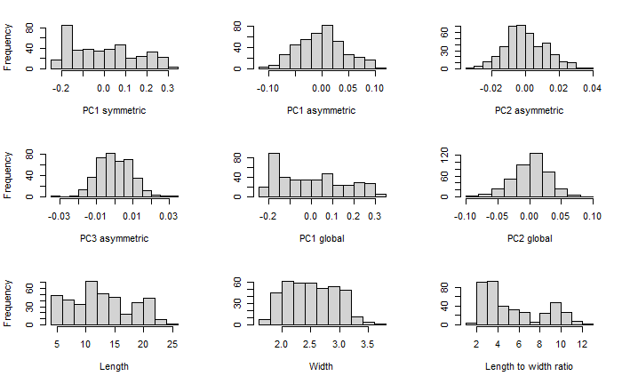

```r
hist(traits_merged$Length_to_width_ratio_mean, main = NULL, xlab = "Length to width ratio", ylab = NULL)
```

```r
# if work from the console, reset graphic settings back with dev.off()
```

### Multicollinearity check: overall correlations between variables

#### Way 1

Multicollinearity check: corrplot  
Get correlation values (Spearman coefficient)

```r
traits_merged_forCorr <- dplyr::select(traits_merged,-c("Species_ID", "Image_ID", "Specimen_ID", "N_spores"))
#names(traits_merged_forCorr) this is to get the actual names and to costumize them manually as I do below
names(traits_merged_forCorr) <- c("PC1 symmetric", "PC1 asymmetric", "PC2 asymmetric",
                                  "PC3 asymmetric", "PC1 global", "PC2 global",
                                  "Length", "Width", "Length to width ratio")
M <- cor(traits_merged_forCorr, method="spearman")
```

Computing the p-value of correlations  
To compute the matrix of p-value, a custom R function is used. Source is [here](http://www.sthda.com/english/wiki/visualize-correlation-matrix-using-correlogram)

```r
# mat : is a matrix of data
# ... : further arguments to pass to the native R cor.test function
cor.mtest <- function(mat, ...) {
    mat <- as.matrix(mat)
    n <- ncol(mat)
    p.mat<- matrix(NA, n, n)
    diag(p.mat) <- 0
    for (i in 1:(n - 1)) {
        for (j in (i + 1):n) {
            tmp <- cor.test(mat[, i], mat[, j], ...)
            p.mat[i, j] <- p.mat[j, i] <- tmp$p.value
        }
    }
  colnames(p.mat) <- rownames(p.mat) <- colnames(mat)
  p.mat
}
```

Get p (significance) values for Spearman correlation coefficient These could not be estimated for all cross-comparisons, apparently due to small data size.

```r
p.mat <- cor.mtest(M, method="spearman", exact=FALSE)
```

Plot correlation values with highlighting only significant (at p=0.05) correlation values

```r
library(corrplot)
col <- colorRampPalette(c("#4477AA", "#77AADD", "#FFFFFF", "#EE9988", "#BB4444"))


tiff(file = here::here("3_results", "fig_corr.tiff"), height = 16.5, width = 16.5, units = 'cm', res = 600,
     compression = "lzw", family = "sans")
corrplot(M, method="color", col=col(200),
         type="upper",
         addCoef.col = "black", # Add coefficient of correlation
         tl.col="black", tl.srt=45, #Text label color and rotation
         # Combine with significance
         p.mat = p.mat, sig.level = 0.05, insig = "blank",
         # hide correlation coefficient on the principal diagonal
         diag=FALSE)
dev.off()
```

```r
# # pdf
# pdf(file = here::here("3_results", "fig_corr.pdf"), height=6.5, width=6.5)
# corrplot(M, method="color", col=col(200),
#          type="upper",
#          addCoef.col = "black", # Add coefficient of correlation
#          tl.col="black", tl.srt=45, #Text label color and rotation
#          # Combine with significance
#          p.mat = p.mat, sig.level = 0.05, insig = "blank",
#          # hide correlation coefficient on the principal diagonal
#          diag=FALSE)
# dev.off()
#
#
# # png
# png(file = here::here("3_results", "fig_corr.png"), height = 16.5, width = 16.5, units = 'cm', res = 500)
# corrplot(M, method="color", col=col(200),
#          type="upper",
#          addCoef.col = "black", # Add coefficient of correlation
#          tl.col="black", tl.srt=45, #Text label color and rotation
#          # Combine with significance
#          p.mat = p.mat, sig.level = 0.05, insig = "blank",
#          # hide correlation coefficient on the principal diagonal
#          diag=FALSE)
# dev.off()
```

#### Way 2

Multicollinearity check: original data: psych

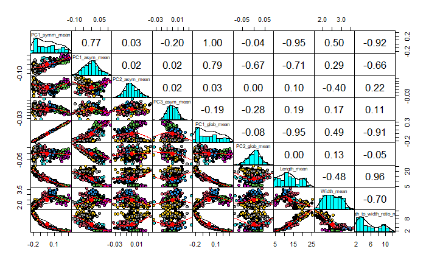

```r
psych::pairs.panels(traits_merged[,4:12], gap = 0, bg = c(1:10)[factor(traits_merged$Species_ID)], pch = 21)
```

Multicollinearity check:log-transformed data: psych: does not change much and kept just for documentation

```r
# psych::pairs.panels(log2(traits_merged[,4:12]), gap = 0, pch = 21, bg = c(1:10)[factor(traits_merged$Species_ID)])
```

#### Way 3

Multicollinearity check: original data: ggplot version

```r
# GGally::ggpairs(traits_merged[,4:12])
```

## Discriminant analysis

The non-normal distribution and unequal variance are present. This prevents from using linear discriminant analysis or quadratic discriminant analysis. I will use flexible discriminant analysis.

My code is inspired by [this post](https://rstudio-pubs-static.s3.amazonaws.com/35817_2552e05f1d4e4db8ba87b334101a43da.html)

Universal function for my discriminant analysis of fungal spores:

```r
myFDA <- function(y, x, mydata, part, rep){
  # seed for reproducibility
  set.seed(12345)

  succ <- dim(rep)
  for (k in 1:rep) {

  # define train and test data
  training_samples <- caret::createDataPartition(mydata[, y], p = part, list = FALSE)

  train_data <- mydata[training_samples, ]
  test_data <- mydata[-training_samples, ]

  # flexible discriminant analysis
  m <- mda::fda(paste(y, '~',  x), data = train_data)
  # table with predictions for test data
  tablin <- table(factor(test_data[, y]), predict(m, test_data))

  # count corrrect predictions = values that are not in the diagonal of "tablin"
  succ[k] <- sum(diag(tablin))/nrow(test_data)
  }
  return (mean(succ))
}
```

Now apply the function to particular spore traits:

```r
# Symmetric shape variation
succ_S <- myFDA('Species_ID', 'PC1_symm_mean', mydata = traits_merged, part = 0.7, rep = 1000)

# Asymmetric shape variation
succ_A <- myFDA('Species_ID', 'PC1_asym_mean + PC2_asym_mean + PC3_asym_mean', mydata = traits_merged, part = 0.7, rep = 1000)

# Global shape variation
succ_G <- myFDA('Species_ID', 'PC1_glob_mean + PC2_glob_mean', mydata = traits_merged, part = 0.7, rep = 1000)

# Length + width
succ_LW <- myFDA('Species_ID', 'Length_mean + Width_mean', mydata = traits_merged, part = 0.7, rep = 1000)

#  Length to width ratio
succ_Q <- myFDA('Species_ID', 'Length_to_width_ratio_mean', mydata = traits_merged, part = 0.7, rep = 1000)

# Total variation as Q & size
succ_QLW <- myFDA('Species_ID', 'Length_to_width_ratio_mean + Length_mean + Width_mean', mydata = traits_merged, part = 0.7, rep = 1000)

# Total variation as global shape + size
succ_GLW <- myFDA('Species_ID', 'PC1_glob_mean + PC2_glob_mean + Length_mean + Width_mean', mydata = traits_merged, part = 0.7, rep = 1000)

# Total variation shape symmetric + asymmetric & size
succ_SALW <- myFDA('Species_ID', 'PC1_symm_mean +
               PC1_asym_mean + PC2_asym_mean + PC3_asym_mean +
               Length_mean + Width_mean', mydata = traits_merged, part = 0.7, rep = 1000)
```

All success rates in a single table

```r
succ_all <- t(data.frame(succ_S,
                         succ_A,
                         succ_G,
                         succ_LW,
                         succ_Q,
                         succ_QLW,
                         succ_GLW,
                         succ_SALW))
succ_all
```

```
               [,1]
succ_S    0.5794741
succ_A    0.4689569
succ_G    0.6152328
succ_LW   0.5905603
succ_Q    0.5381552
succ_QLW  0.5941121
succ_GLW  0.6243362
succ_SALW 0.6469397
```

Re-format and plot the identification success rates

```r
succ_all_df <- data.frame(succ_all)
# row.names(data.frame(succ_all)) # to retrieve the names of the predictors and adjust them
# succ_all_df$Predictors <- row.names(data.frame(succ_all))
succ_all_df$Predictors <- c('S', 'A', 'G', 'LW', 'Q', 'QLW',  'GLW', 'SALW')

names(succ_all_df)[1] <- 'Success'
succ_all_df[1] <- round(succ_all_df[1]*100, 1) # switch to percents

# make predicors to be factors, instead of characters. This will keep their original order while plotting.
succ_all_df$Predictors <- factor(succ_all_df$Predictors, levels = succ_all_df$Predictors)
p <- ggplot(succ_all_df, aes(x=reorder(Predictors, Success), y=Success)) +
  geom_bar(stat="identity", fill="steelblue") +
  xlab('Predictors') +
  ylab('Identification success rate, %') +
  coord_flip(ylim = c(45, 65)) +
  geom_text(aes(label=Success), vjust=0.5, hjust = 1.4, size = 4, color="white")
  theme(axis.title = element_text(size = 16), axis.text = element_text(size = 12))
```

[output not shown]

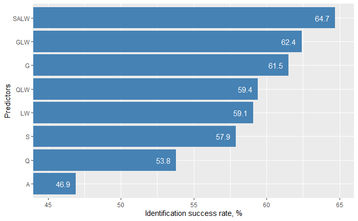

```r
p
```

Save id success rates plot

```r
# tiff
tiff(file = here::here("3_results", "fig_success_1000rep.tiff"), height= 9, width=12, units = 'cm', res = 600,
     compression = "lzw", family = "sans")
print(p)
dev.off()
```

```r
# png(file = here::here("3_results", "bar_dis.png"), height= 9, width=12, units = 'cm', res = 300)
# print(p)
# dev.off()
```

## Phylogenetic tree that justifies the assignment of specimens to species

### Load DNA sequences to R memory

```r
library(Biostrings)
conflicted::conflict_prefer("strsplit", "Biostrings")
seq <- readDNAStringSet(here::here("2_1_data_dna", "202103", "its_30seq.fasta"))
```

```
reading FASTA file C:/Users/aordy/OneDrive/Documents/Projects/ARTS/2_studies/1_size_vs_shape/3_latest/2_1_data_dna/202103/its_30seq.fasta: ignored 5 invalid one-letter sequence codes
```

```r
# seq@ranges@NAMES # seq names are here, work on names later if necessary
```

### Multiple sequence alignment (MSA)

```r
library(msa)
ali_XString <- msa::msa(seq, type="dna", method="Muscle")
#the run took 11.45 seconds for 48 ITS sequences on my Dell laptop in Aug 2020

library(ape)
# convert the alignment to DNAbin
ali_bin <- as.DNAbin(ali_XString)
```

### Plot MSA

#### Untrimmed MSA

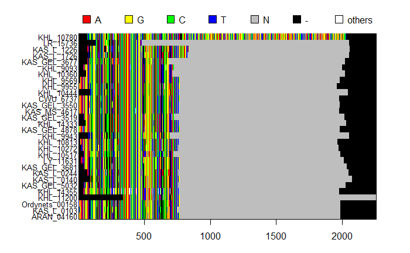

```r
par(mar=c(3,7,3,3))
image(ali_bin, cex.lab = 0.8)
```

#### Trimmed MSA

Trimm the ends of aligment and plot again

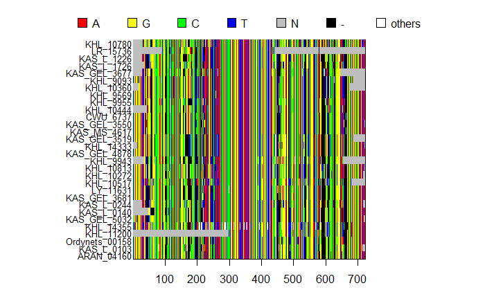

```r
# package ips is required
# to make ips working properly, I had to install XML package from binary in the following way:
# install.packages("XML", type = "binary")
library(ips)
ali_trimmed <- trimEnds(ali_bin, min.n.seq = 15)
par(mar=c(3,10,3,9))
image(ali_trimmed, cex.lab = 0.8)
```

### Maximum Likelihood phylogenetic analysis

```r
library(phangorn)
conflicted::conflict_prefer("rename", "S4Vectors")
```

```
[conflicted] Removing existing preference
[conflicted] Will prefer S4Vectors::rename over any other package
```

```r
mt <- modelTest(phyDat(ali_trimmed), model="all", control = pml.control(trace = 0))
```

```
negative edges length changed to 0!
```

```r
# choose best model to your preferred information criteria
bestModel <- mt$Model[which.min(mt$AIC)]
# "some R magic" - citation from Klaus Schliep
env <- attr(mt, "env")
fitStart <- eval(get(bestModel, env), env=env)
# optimize model
fit.nni <- optim.pml(fitStart, rearrangement="NNI", control = pml.control(trace = 0))
# bootstrap analysis
bs <- bootstrap.pml(fit.nni, bs=1000, optNni=TRUE, control = pml.control(trace = 0))
```

[output not shown]

[output not shown]

[output cut: 945 more lines]

[output not shown]

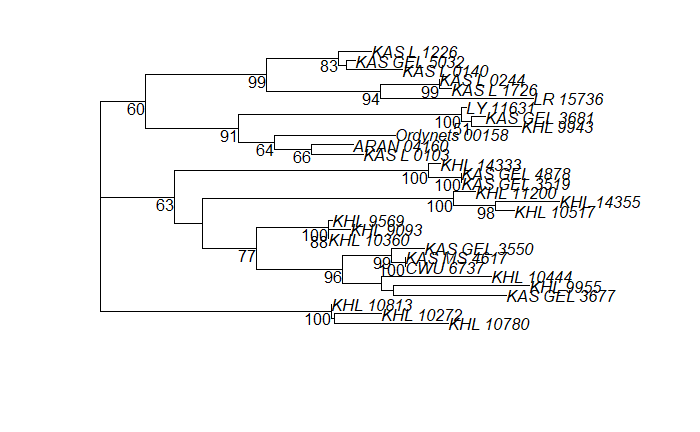

```r
# save the tree with bootstrap supports as node labels in phylo object
tree.bs <- plotBS(fit.nni$tree, bs, type="phylo")
```

What was the best substitution model?

```r
bestModel
```

```
[1] "TrN+G+I"
```

Save the tree to file

```r
ape::write.tree(tree.bs, file = here::here("3_results", "tree_1000bs.newick"))
```

### Custom plotting of the tree

```r
# reroot the tree
tree.bs <- root(tree.bs, c("KHL_10272", "KHL_10780", "KHL_10813"), resolve.root = T)

library(ggtree)
library(ggplot2)

# add species names if not already done in the morphometric part of the script
sp_names <- read.csv(here::here("3_results", "species_names.csv"),  sep=",", stringsAsFactors=FALSE)
# now a complex operator will add the species names to the object
# it aligns the species names to sequence labels correctly - I've checked this manually
# there will be an error message that the number of replaced elements does not equal the
# total number of elements in the labels, but it is OK because we only assign the species names to the
# terminal node labels = tip labels, and not to internal node labels (which are bootstrap supports here)
p0 <- ggtree(tree.bs) %<+% sp_names
```

Now setting all aestetics

```r
p1 <- p0 +
  geom_tree(size=0.1) +
  geom_tiplab(aes(color = Species_ID), key_glyph = draw_key_point, size=2, align=F, hjust=-0.01) +
  geom_text2(aes(subset = !isTip, label = round(as.numeric(label), digits = 0)), size = 2, vjust = -0.7, hjust = 1.2) +
  geom_treescale(linesize = 0.5, fontsize = 2, x = 0.85, y = 16.5) +
  geom_text(label="substitutions per site", x=1, y=16.0,
            size = 6 / .pt, fontface = 'plain', family = 'sans', stat = "unique") +
  # this 'stat = 'unique'' makes the text font the same as inner ggploting
  xlim(-0.04, 1.2) +
  theme(legend.position=c(0.8, 0.81),
        legend.background = element_rect(),
        legend.key = element_blank(), # removes the border
        legend.key.size = unit(0.4, 'cm'),# sets overall area/size of the legend
        legend.text = element_text(size = 6), # text size
        title = element_text(size = 7)) +
  theme(plot.margin = unit(c(0.1, 0, 0.1, 0.2), "cm"))
  # +labs(col="Subulicystidium \n species") # would change legend title
```

Print the tree to a file(s)

```r
# tiff via tiff()
tiff(filename = here::here("3_results", "fig_tree_1000bs.tiff"), height= 12, width=9, units = 'cm', res = 600,
     compression = "lzw", family = "sans")
print(p1)
dev.off()
```

```r
# tiff via ggsave
# ggsave(filename = here::here("3_results", "fig_tree_20BS.tiff"), plot = p1, height= 12, width=9, units = 'cm', dpi = 400)

# # pdf
# pdf(file = here::here("3_results", "fig_tree.pdf"), height=5.0, width=3.5)
# print(p1)
# dev.off()
#
# # png
# png(file = here::here("3_results", "fig_tree.png"), height= 12, width=9, units = 'cm', res = 500)
# print(p1)
# dev.off()
```

## References

Generates the bibliography of all used R packages and R version, and a paragraph for the Methods part of thesis (or paper)

```r
# package "report" has to be installed https://easystats.github.io/report/articles/report.html
report::report(sessionInfo())
```

```
Analyses were conducted using the R Statistical language (version 4.0.3; R Core Team, 2020) on Windows 10 x64 (build 19041), using the packages ggpubr (version 0.4.0; Alboukadel Kassambara, 2020), ggtree (version 2.4.1; Guangchuang Yu. Using ggtree to visualize data on tree-like structures. Current …

References
----------
  - Alboukadel Kassambara (2020). ggpubr: 'ggplot2' Based Publication Ready Plots. R package version 0.4.0. https://CRAN.R-project.org/package=ggpubr
  - Guangchuang Yu. Using ggtree to visualize data on tree-like structures. Current Protocols in Bioinformatics, 2020, 69:e96. doi: 10.1002/cpbi.96
  - H. Pagès, M. Lawrence and P. Aboyoun (2020). S4Vectors: Foundation of vector-like and list-like containers in Bioconductor. R package version 0.28.0. https://bioconductor.org/packages/S4Vectors
  - H. Pagès, P. Aboyoun, R. Gentleman and S. DebRoy (2020). Biostrings: Efficient manipulation of biological strings. R package version 2.58.0. https://bioconductor.org/packages/Biostrings
  - H. Wickham. ggplot2: Elegant Graphics for Data Analysis. Springer-Verlag New York, 2016.
  - Hadley Wickham (2019). conflicted: An Alternative Conflict Resolution Strategy. R package version 1.0.4. https://CRAN.R-project.org/package=conflicted
  - Hadley Wickham (2019). stringr: Simple, Consistent Wrappers for Common String Operations. R package version 1.4.0. https://CRAN.R-project.org/package=stringr
  - Hadley Wickham and Jim Hester (2020). readr: Read Rectangular Text Data. R package version 1.4.0. https://CRAN.R-project.org/package=readr
  - Hadley Wickham, Romain François, Lionel Henry and Kirill Müller (2021). dplyr: A Grammar of Data Manipulation. R package version 1.0.3. https://CRAN.R-project.org/package=dplyr
  - Heibl C. 2008 onwards. PHYLOCH: R language tree plotting tools and interfaces to diverse phylogenetic software packages. http://www.christophheibl.de/Rpackages.html.
  - Hervé Pagès and Patrick Aboyoun (2020). XVector: Foundation of external vector representation and manipulation in Bioconductor. R package version 0.30.0. https://bioconductor.org/packages/XVector
  - Kirill Müller (2020). here: A Simpler Way to Find Your Files. R package version 1.0.1. https://CRAN.R-project.org/package=here
  - Lawrence M, Huber W, Pag\`es H, Aboyoun P, Carlson M, et al. (2013) Software for Computing and Annotating Genomic Ranges. PLoS Comput Biol 9(8): e1003118. doi:10.1371/journal.pcbi.1003118
  - Matt Dowle and Arun Srinivasan (2020). data.table: Extension of `data.frame`. R package version 1.13.4. https://CRAN.R-project.org/package=data.table
  - Orchestrating high-throughput genomic analysis with Bioconductor. W. Huber, V.J. Carey, R. Gentleman, ..., M. Morgan Nature Methods, 2015:12, 115.
  - Paradis E. & Schliep K. 2019. ape 5.0: an environment for modern phylogenetics and evolutionary analyses in R. Bioinformatics 35: 526-528.
  - R Core Team (2020). R: A language and environment for statistical computing. R Foundation for Statistical Computing, Vienna, Austria. URL https://www.R-project.org/.
  - Schliep K.P. 2011. phangorn: phylogenetic analysis in R. Bioinformatics, 27(4) 592-593
  - Taiyun Wei and Viliam Simko (2017). R package "corrplot": Visualization of a Correlation Matrix (Version 0.84). Available from https://github.com/taiyun/corrplot
  - U. Bodenhofer, E. Bonatesta, C. Horejs-Kainrath, and S. Hochreiter (2015) msa: an R package for multiple sequence alignment. Bioinformatics 31(24):3997-9999. DOI: 10.1093/bioinformatics/btv176.
```

End of the script.